# ProjectWriteUp2

## Project Write Up 2- Aniela Jensen

### Prework

```python
import matplotlib.pyplot as plt
import numpy as np
import pandas as pd
import seaborn as sns

from sklearn import cluster, datasets, metrics, model_selection, linear_model
```

```python
sp= pd.read_csv("student_habits_performance.csv")
```

### Introduction

Link to dataset: https://www.kaggle.com/datasets/jayaantanaath/student-habits-vs-academic-performance

Description of Dataset:

- This synthetic dataset explores how various lifestyle habits influence academic performance in students. The dataset contains 16 variables and 1,000 observations, recording students' key habits and observations such as daily study hours, sleep duration, mental health ratings, exercise frequency, attendance percentage, and exam scores.

Important variables:

- Study Hours per day
  - Average daily study time
- Sleep Hours
  - Average daily sleep
- Mental Health Rating
  - Self-assessed mental health rating between 1(very poor)-10(excellent)
- Exercise Frequency
  - Times exercised per week
- Attendance Percentage
  - Class attendance percentage (1-100)
- Gender
  - Male/female/other
- Exam Score
  - Final exam score (1-100)

Data Modifications:

- Put study hours into labeled bins
- Put mental health ratings into three labeled bins (low, medium, high)
- Ended up dropping the student Id column, but not until after I accidentally one-hot encoded it.

```python
sp.describe()
```

|  | age | study_hours_per_day | social_media_hours | netflix_hours | attendance_percentage | sleep_hours | exercise_frequency | mental_health_rating | exam_score |
| --- | --- | --- | --- | --- | --- | --- | --- | --- | --- |
| count | 1000.0000 | 1000.00000 | 1000.000000 | 1000.000000 | 1000.000000 | 1000.000000 | 1000.000000 | 1000.000000 | 1000.000000 |
| mean | 20.4980 | 3.55010 | 2.505500 | 1.819700 | 84.131700 | 6.470100 | 3.042000 | 5.438000 | 69.601500 |
| std | 2.3081 | 1.46889 | 1.172422 | 1.075118 | 9.399246 | 1.226377 | 2.025423 | 2.847501 | 16.888564 |
| min | 17.0000 | 0.00000 | 0.000000 | 0.000000 | 56.000000 | 3.200000 | 0.000000 | 1.000000 | 18.400000 |
| 25% | 18.7500 | 2.60000 | 1.700000 | 1.000000 | 78.000000 | 5.600000 | 1.000000 | 3.000000 | 58.475000 |
| 50% | 20.0000 | 3.50000 | 2.500000 | 1.800000 | 84.400000 | 6.500000 | 3.000000 | 5.000000 | 70.500000 |
| 75% | 23.0000 | 4.50000 | 3.300000 | 2.525000 | 91.025000 | 7.300000 | 5.000000 | 8.000000 | 81.325000 |
| max | 24.0000 | 8.30000 | 7.200000 | 5.400000 | 100.000000 | 10.000000 | 6.000000 | 10.000000 | 100.000000 |

### Hypothesis Generation and Exploration

Questions:

- How do study hours per day and gender together affect exam scores?
- How does students’ mental health status relate to the distribution of their exam score?

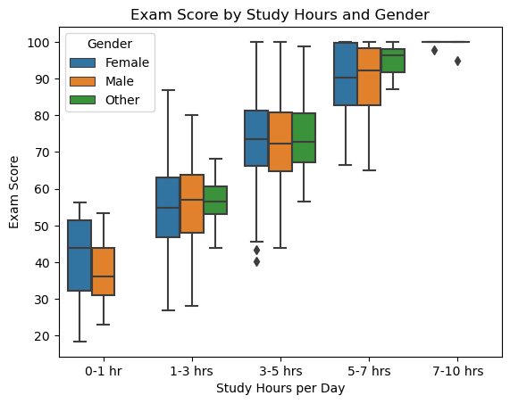

```python
bins = [0, 1, 3, 5, 7, 10]
labels = ['0-1 hr', '1-3 hrs', '3-5 hrs', '5-7 hrs', '7-10 hrs']
sp['study_hours_group'] = pd.cut(sp['study_hours_per_day'], bins=bins, labels=labels, right=False)
sp['study_hours_group'] = pd.Categorical(sp['study_hours_group'], categories=labels, ordered=True)

plt.figure()
sns.boxplot(data=sp,x='study_hours_group',y='exam_score',hue='gender')

plt.title('Exam Score by Study Hours and Gender')
plt.xlabel('Study Hours per Day')
plt.ylabel('Exam Score')
plt.legend(title='Gender')
plt.show()
```

Interpretation of plot:

- This plot helps answer the question 'How do study hours per day and gender together affect exam scores?'. The box plot demonstrates the relationship between study hours per day and exam score, broken down by gender. The overall trend shows that students who studied more hours per day tended to achieve higher exam scores. Both male and female groups show a similar upward trend, suggesting that the impact of study time is independent of gender.

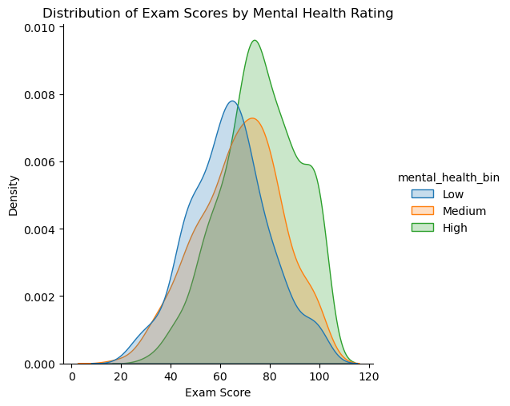

```python
bins = [0, 3, 6, 10]
labels = ['Low', 'Medium', 'High']
sp['mental_health_bin'] = pd.cut(sp['mental_health_rating'], bins=bins, labels=labels)

sns.displot(data=sp,x="exam_score",hue="mental_health_bin",kind="kde",fill=True,)

plt.title("Distribution of Exam Scores by Mental Health Rating")
plt.xlabel("Exam Score")
plt.ylabel("Density")
plt.show()
```

Interpretation of plot:

- This plot helps answer the question "How does students’ mental health status relate to the distribution of their exam score?". The distribution plot shows that students with higher mental health ratings tend to achieve higher exam scores. The green curve (high mental health) peaks further to the right,indicating better overall performance, while the blue curve (low mental health) peaks earlier and has a longer tail toward lower scores. This suggests a positive relationship between mental well-being and exam scores.

### Machine Learning

#### (1) Fit a machine learning model to predict a quantitative variable in your dataset based on the other variables in your dataset

##### Linear Regression:

Dependent Variable:

- Exam Score

Independent Variables:

- Study hours per day
- sleep hours
- menta health rating
- Exercise Frequency
- Attendance Percentage

```python
X = sp[['study_hours_per_day', 'sleep_hours', 'mental_health_rating', 'attendance_percentage', 'exercise_frequency']]
y = sp['exam_score']

X_train, X_test, y_train, y_test = model_selection.train_test_split(X, y, test_size=0.2, random_state=123)
clf = linear_model.LinearRegression().fit(X_train, y_train)
y_pred = clf.predict(X_test)
y_pred_train = clf.predict(X_train)

print("training r2", metrics.r2_score(y_train, y_pred_train))
print("test r2", metrics.r2_score(y_test, y_pred))
print("RMSD", metrics.mean_squared_error(y_test, y_pred, squared=False))
```

```
training r2 0.8421164802743113
test r2 0.8619709469256223
RMSD 6.450004730683604
```

Interpretation of the results:

- Both the training and test set R-Sqaured are close to eachother so that implies there is no underfitting or overfitting.
- The relatively high R-Squared scores and low RMSD, I would say that this model is suitable for future predictions.

#### (2) Fit a machine learning model to predict a categorical variable in your dataset based on the other variables in your dataset.

##### Logistic Regression:

Dependent Variable:

- extracurricular_participation_Yes

Independent Variables:

- age
- study_hours_per_day
- social_media_hours
- netflix_hours
- attendance_percentage
- sleep_hours
- exercise_frequency
- mental_health_rating
- exam_score

```python
sp_encoded = pd.get_dummies(sp, drop_first=True)
sp_encoded = sp.drop(columns=[col for col in sp.columns if 'student_id' in col])
#I accidentally one-hot encoded the student ID column and then wanted to delete them all

X = sp_encoded.drop(columns=['extracurricular_participation_Yes', 'extracurricular_participation_No'])
y = sp_encoded['extracurricular_participation_Yes']

X_train, X_test, y_train, y_test = model_selection.train_test_split(X, y, test_size=0.2, random_state=111)
reg = linear_model.LogisticRegression(max_iter=1000).fit(X_train, y_train)

y_pred = reg.predict(X_test)
print("Accuracy:", metrics.accuracy_score(y_test, y_pred))

labels = np.unique(y_test)
cm = metrics.confusion_matrix(y_test, y_pred, labels=labels)
pd.DataFrame(cm, index=labels, columns=labels)
```

```
Accuracy: 0.67
```

|  | False | True |
| --- | --- | --- |
| False | 133 | 0 |
| True | 66 | 1 |

Interpretation of the results:

- The model has an accuracy of 67%.
- The model confusion matrix shows that the model corrctly predicticed all of the 133 students that did not participate in extracurricular activities, but the model missed 66 that did. So very good at predicting finding the 'No' answer, but is very poor at finidng 'yes' answers.
- This model isn't very reliable and would not reccomend for future predictions.

### Ethical Considerations

- Because this dataset is synthetic, I do not belive that it crosses any ethicial considerations.

### Conclusion

- Both the visuals were able to help show that exam scores tend to increase as study hours per day increases and for those students who have higher mental health ratings. The visuals also showed that the impact of study time is independent of gender. The linear regression used to predict exam score was fairly accurate and is suitable for future predictions. However, the logistic regression used to predict students that did do extra curricular actrivities ('Yes' answer), was fairly innacurate and not suitable for making future predictions.